# Fish Tissue Contamination Trends in the Great Lakes

GitHub Repsitory:https://github.com/j-narleski/NarleskiThompson_ENV872_EDA_FinalProject

Jaclyn Narleski and Victoria Thompson

December 12, 2024

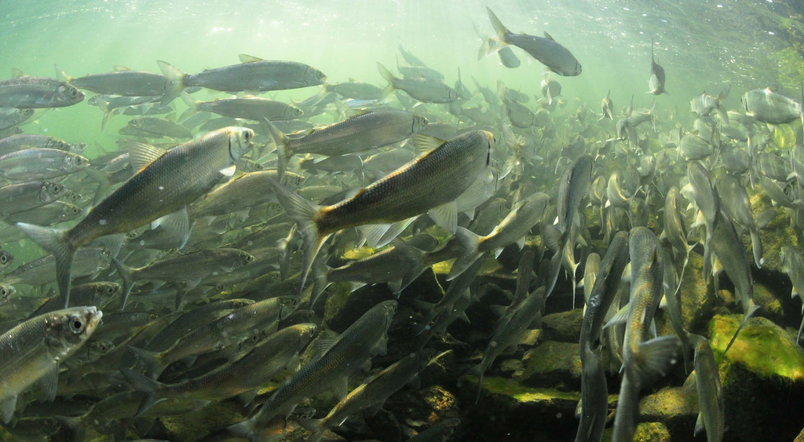

Herring in the Great Lakes. All Rights to Paul Vecsei (9)

# 1 Rationale and Research Questions

The Great Lakes, which collectively represent the largest surface freshwater system on Earth, are critical ecological and economic resources for millions of people. These lakes support diverse aquatic life, serve as a source of drinking water, provide recreational opportunities, and underpin industries such as fishing. However, over the past century, the Great Lakes have been threatened by environmental stressors, including pollution from industrial waste, agricultural runoff, and urban development.[1] The contaminants affecting these ecosystems pose serious risks to both aquatic life and human health.

Fish accumulate pollutants in their tissues, decreasing their health and altering ecological dynamics within the lakes. In 2010, the EPA launched the NCCA (National Coastal Condition Assessment) to “assess the condition of nearshore waters along the marine and Great Lakes coasts of the United States and to evaluate changes affecting the quality of these waters over time”.[2] This project includes sampling and testing fish tissues for particularly harmful long-lasting chemicals, including mercury, PFAS, PCBs, and fatty acids (Table 1.1 ). The EPA hopes that data on these contamination levels will allow them to be better informed on the current risks to fish, and the aquatic and human lives that depend on them.

Between the fragile ecosystems that depend on fish to the entire human populations to rely on them, studying contamination is of the utmost importance. This has led to the development of the following research questions to guide our investigation:

Does average fish tissue contamination vary significantly between each lake within each sampling year?

Are there trends in contaminant levels in each fish species over time?

How do contaminants vary depending on if fish is an open-sea or bottom dweller (niche)?

Table 1.1: Description of the contaminants used in this project.

| Contaminant | Description | Effect on Human Health |
| --- | --- | --- |
| Mercury | A heavy metal that comes from sources such as factory outputs and landfill leaching | Reproductive, developmental, and sensory defects |
| Fatty Acids | Organic compounds found in the tissues of organisms; required in some amounts but negative in excess | Excessive intake can lead to cardiovascular diseases |
| PCBs | Industrial chemicals used in electrical equipment, plastics, and paints | Cancer, reproductive problems, and immune system suppression |
| PFAs | Man-made chemicals found in products that resist oil and grease (i.e. non-stick coatings) and fire-fighting foam | Associated with cancer, liver damage, thyroid disorders, and immune system suppression |

# 2 Dataset Information

The datasets used in this analysis were sourced from the Environmental Protection Agency (EPA) website. They were selected from available National Coastal Condition Assessments (NCCA), which are surveys designed to assess long-term conditions of nearshore waters along the coasts of the Great Lakes. Our data specifically involves the data collected from Fish Fillet Tissue studies, where samples of fish muscle from commonly caught recreational fish species are taken and analyzed for mercury, PFAs (per- & polyfluoroalkl substances), PCB (polychlorinated biphenyls) Congeners & Aroclors, and Omega-3 & Omega-6 fatty acids. The EPA uses the results from these studies to evaluate the water quality of the Great Lakes and more specifically, determine the health impacts humans may have from consuming fish caught in the Great Lakes.

Fish contaminant data is collected using the following procedures, per the 2020 NCCA Field Operations Manual:

1. Sites are randomly selected along U.S. coasts of the Great Lakes
2. Crews collect fish at all NCCA sites, yielding a minimum total of 300g total mass per target species
3. Fish are identified, measured, labelled, frozen, and brough to a lab
4. Specimens are cleaned to prevent contamination with non-marine chemicals
5. Fish are filleted (scales are removed, but skin and belly are left intact)
6. A variety of lab procedures are performed in accordance with EPA guidelines to determine the lipid content, concentrations of metals, pesticides, and PCBs in each fish

The Environmental Protection Agency has conducted periodic studies over the past 15 years assessing the coastal conditions of marine and the Great Lakes shores. We focus on data from 2010, 2015, and 2020. The basic structure of each raw data file is described below (Table 2.1 ).

Table 2.1: Description of the columns in the dataset.

| Column.Name | Description |
| --- | --- |
| EPA Region | The EPA Region in which the sample was collected |
| State | 2-letter abbreviation for the state in which the sample was collected |
| Lake Name | The Great Lake the sample is from |
| Site ID | “NGL” + site selection year + state + 4-digit site location |
| EPA Sample ID | Individual numeric code assigned to each fish species |
| Species ID | Taxonomic name of each species |
| Scientific Name | Taxonomic family of each species |
| Common Name | Common name of each species |
| Family | Taxonomic family of each species |
| Niche | Codified ecological niche of the fish sampled; “BD” is “Benthic-Demersal” & “P” is “Pelagic” |
| Analyte | The contaminant being measured |
| Abbreviation | The abbreviation for the contaminant being measured |
| CAS Number | A unique identifier assigned to chemical substances by the Chemical Abstracts Service |
| Amount | Amount of contaminant |
| Unit.1 | The original unit the chemical was measured in (‘ng/g’ for Mercury, PFA, PCB; ‘mg/g’ for Fatty Acids) |
| Unit.2 | The amount of chemical converted to common units (‘ppb’ for Mercury, PFA, PCB; ‘ug/g’ for Fatty Acids) |
| MDL | Method Detection Limit - the minimum concentration of a substance that can be reliably detected and reported with 99% confidence |
| QL | Quantification Limit - the lowest concentration that can be reliably measured within a certain level of precision and accuracy |
| Lab Flag | Unique identifier for the lab used |
| SCC Code | Code for the container the fish was stored in between catching and processing |
| Comment | Comment on results input by researcher |

*adapted from 2020 GLHHFTS Fish Tissue Data Dictionary for Mercury, PCBs, and PFAS Results November 2023*.

## 2.1 Dataset Wrangling Procedures

Each of the 5-year publications from the EPA contains 4 separate data files arranged by contaminant (Mercury, PFAS, PCBs, Fatty Acids). There are also 3 metadata files and 3 quality assurance reports for each.[3] It’s important to note that the data files contained two .xlsx sheets - one containing sample measurements associated with each lake and the other, fish species and their niches - see these were combined manually. Each of the 4 separate contaminant data files were then loaded into R as raw .xlsx files. The columns from Table 2.1 were selected from the raw file, and a new column was added for the collection year. This was repeated for all 12 datasets (4 contaminants for each of 3 years). There are slight variations in the dataset formatting between years, leading to differences in the pipe function to account for them. For example, some columns are renamed as to all have a consistent naming conventions. Any NA values for the amount of contaminants recorded were converted to 0 to make analysis easier. Each wrangled dataset was reassigned to a “processed” .csv file for analysis.

## 2.2 Summary of Data Structure

The basic structure of each of the raw datasets can be found in Table 2.1. The specific variables being investigated from each of the processed files can be found below (Table 2.2 ). They vary in units, described in Table 2.3. Additionally, while the total fatty acid content was combined, the types that were used for our specific study found in the data are listed along with their abbreviations (Table 2.5). This is due to the fact that some of the analytes in the 2015 and 2020 fatty acid studies were not measured in the 2010 study, and do not have nearly as much research and information on their impacts in comparison to the other analytes found in all 3 studies. This went for the PFA content as well - the research behind PFAs is ongoing; however, this past year the EPA has recently implemented standards for specific PFAs (listed below) (Table 2.4) in drinking water since they are now a cause for concern.

Table 2.2: Description of the variables in the dataset.

[output not shown]

Table 2.3: Units of measurement for each contaminant.

| Contaminant | Unit 1 (Original) | Unit 2 (Converted) |
| --- | --- | --- |
| Mercury | ng/g (nanograms per gram) | ppb (parts per billion) |
| Fatty Acids | mg/g (milligrams per gram) | ug/g (micrograms per gram) |
| PCBs | ng/g (nanograms per gram) | ppb (parts per billion) |
| PFAs | ng/g (nanograms per gram) | ppb (parts per billion) |

Table 2.4: Types of PFAs, their abbreviations, and the maximum contaminant level allowed in drinking water.

| PFA | Abbreviation | Maximum Contaminant Level (MCL) |
| --- | --- | --- |
| Perfluorooctanoate | PFOA | 4.0 ppt |
| Perfluorooctanesulfonate | PFOS | 4.0 ppt |
| Perfluorohexane sulfonate | PFHxS | 10 ppt |
| Perfluorononanoate | PFNA | 10 ppt |
| Hexafluoropropylene oxide dimer acid | HFPO-DA | 10 ppt |

Table 2.5: Types of fatty acids and their abbreviations.

| Fatty Acid | Type | Abbreviation |
| --- | --- | --- |
| alpha-Linolenic acid | Omega-3 | ALA |
| Docosahexaenoic acid | Omega-3 | DHA |
| Docosapentaenoic acid | Omega-3 | DPA |
| Eicosapentaenoic acid | Omega-3 | EPA |
| Eicosatrienoic acid | Omega-3 | ETE |
| Linolenic acid | Omega-6 | LA |

# 3 Exploratory Analysis

Before beginning analysis aimed at answering our research questions, we explore it in several ways. First, to orient ourselves spatially, we map the all of the sites sampled in 2020. We aren’t able use specific site location in our analysis, due to a lack of spatial data in the 2010 and 2015 datasets. However, it is noted in the metadata (from which we extract the sites and their coordinates) that many of the 2020 sites were locations revisited from previous sample years (Figure 3.1).[4] Note that the spacing between each sample site and their distance from the shore is an intentional part of the design that ensures the nearshore area of each lake is properly and randomly sampled.

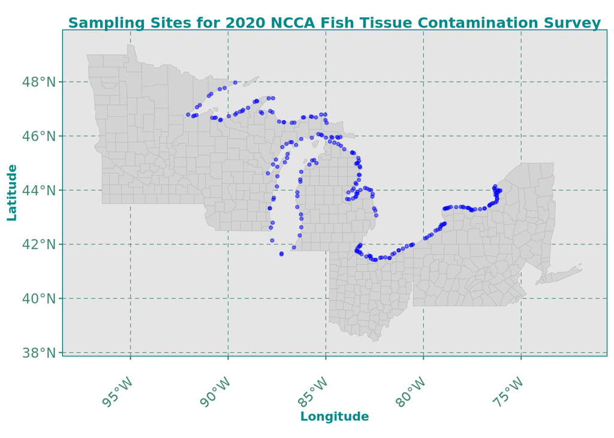

Figure 3.1: Map of nearshore sampling sites used for NCCA 2020

To better inform our statistical methods for answering our research questions, we explored the presence of each contaminant each year based on (1) lake, (2) fish, and (3) niche. Through the act of processing data for exploration, we discovered some gaps and inconsistencies in data recording that rendered us unable to explore certain aspects of each contaminant. Further, we found inconsistencies in the naming of fish (particularly in capitalization) that required secondary wrangling.

## 3.1 Mercury

Data on mercury is complete across all three time periods. Visualizations of the relationships between mean mercury levels and lake (Huron, Superior, Erie, Michigan, and Ontario), fish species, and niche (Benthic and Pelagic) are below (Figure 3.2, Figure 3.3, and Figure 3.4).

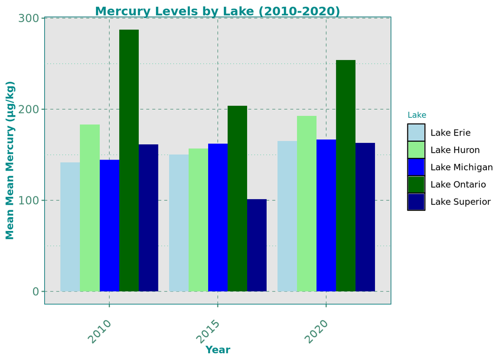

Figure 3.2: Exploratory analysis of mean mercury levels in each of the Great Lakes

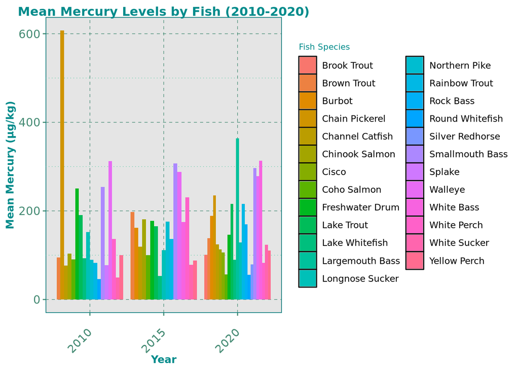

Figure 3.3: Exploratory analysis of mean mercury levels in each sampled fish species

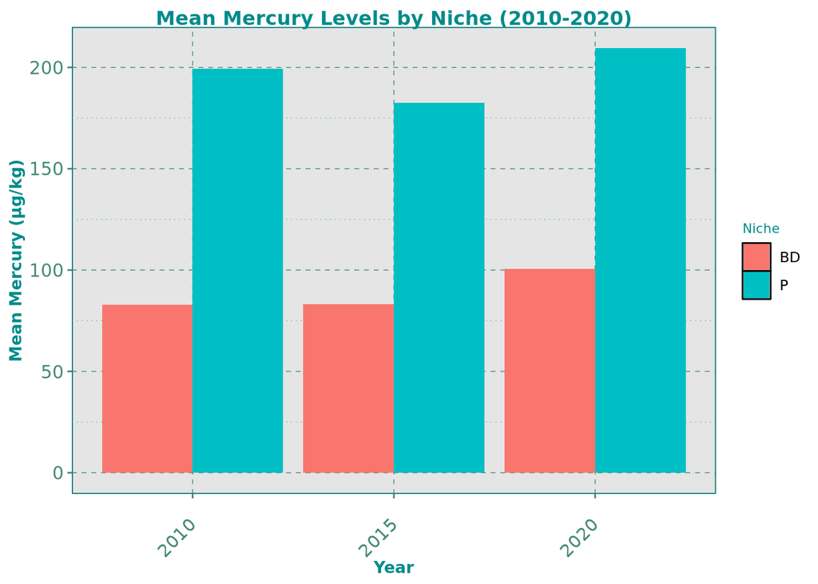

Figure 3.4: Exploratory analysis of mean mercury levels by fish niche

## 3.2 PCBs

PCBs (Polychlorinated Biphenyls) are also a complete dataset. Visualizations are shown below (Figures 3.5, 3.6, 3.7).

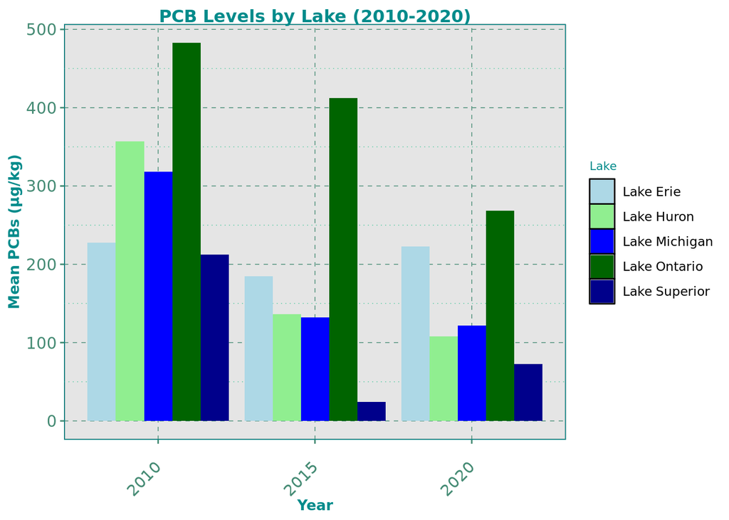

Figure 3.5: Exploratory analysis of mean PCB levels in each of the Great Lakes

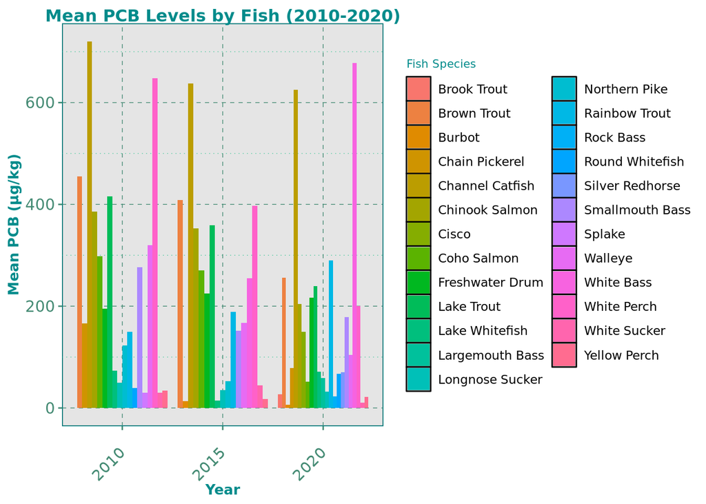

Figure 3.6: Exploratory analysis of mean PCB levels in each sampled fish species

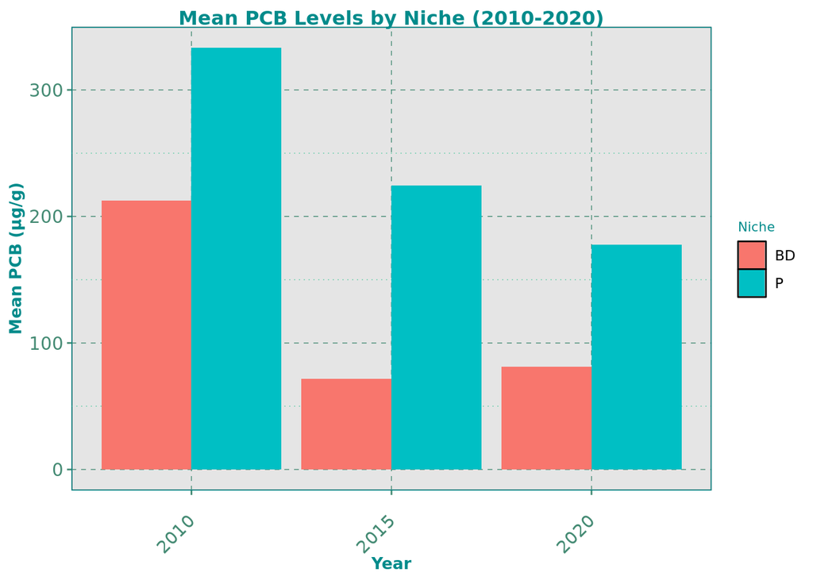

## 3.3 Fatty Acids

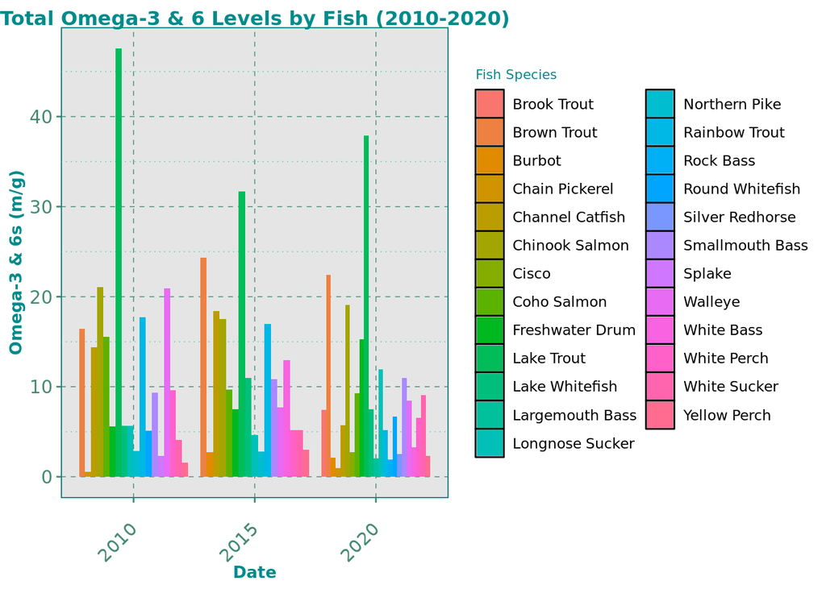

Figure 3.8: Exploratory analysis of mean fatty acid levels by fish species

## 3.4 PFAs

Like Fatty Acids, there are multiple PFAs (Per- and Polyfluoroalkyl Substances) that were measured in the sampling. Of the ones included, we filtered out four specifically, due to their known negative effect on human health (Perfluorooctanoate (PFOA), Perfluorooctanesulfonate (PFOS), Perfluorohexane sulfonate (PFHxS),and Perfluorononanoate (PFNA)). They are also specifically monitored by the EPA across other projects, and have clear levels where they become unsafe for consumption.[6] We used mean PFA values for each lake, (Figure 3.9 ), each fish species (Figure 3.10 ), and for each niche (Figure 3.11 ).

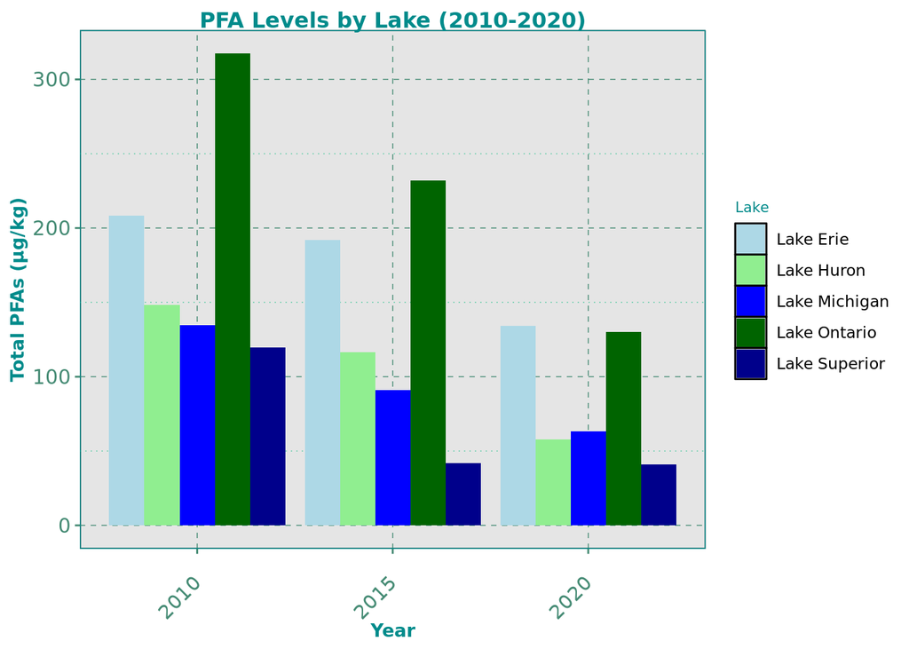

Figure 3.9: Exploratory analysis of total PFA levels by lake

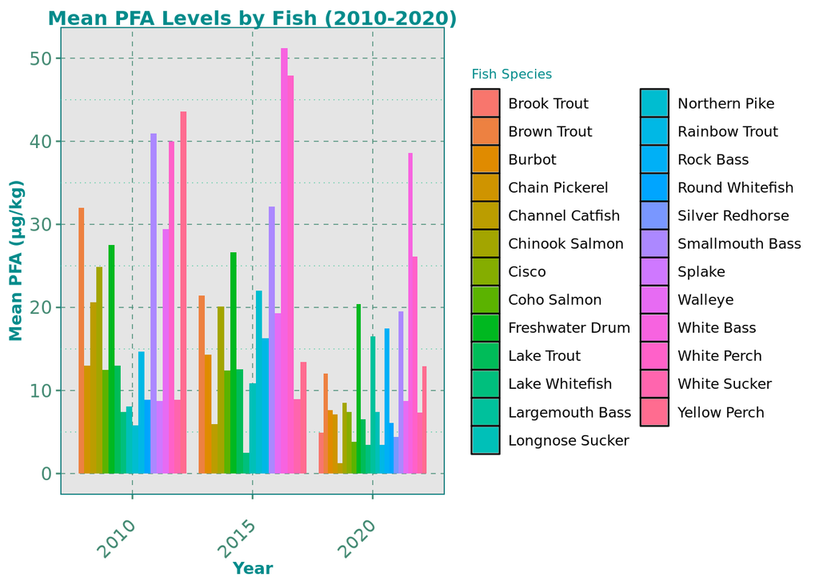

Figure 3.10: Exploratory analysis of mean PFA levels by fish species

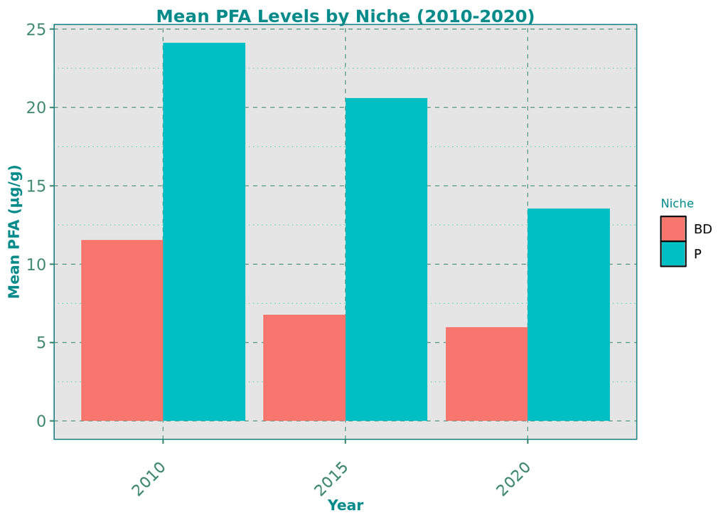

Figure 3.11: Exploratory analysis of mean PFA levels by fish niche

# 4 Analysis

## 4.1 Question 1: Does average fish tissue contamination vary significantly between each lake within each sampling year?

For this question, we use an **ANOVA** (Analysis of Variance) to compare the means contaminants of fish sourced from each lake to determine if there are statistical differences between them. We test the **null hypothesis that there is no effect of lake on contaminant levels** (i.e. there is not a statistically significant difference between them). Since we are focusing on one categorical independent variable (the lakes), we employ a one-way ANOVA. We perform nine ANOVAs, one for each of the contaminants (3) and one for each year (3). The results of the 9 ANOVAs are recorded in Table 4.1 below. The degrees of freedom for each ANOVA is 4.

*Note: Because of the complex and incomplete Fatty Acid data, as well as its mixed effect on human health, we exclude Fatty Acids from this analysis*.

Table 4.1: ANOVA results of mean contaminant levels found in fish samples from each of the Great Lakes from 3 sampling years.

| Contaminant | Year | F Value | P-value | Significant? (p<0.05) |
| --- | --- | --- | --- | --- |
| Mercury | 2010 | 6.397 | 8.74e-05 | YES |
| Mercury | 2015 | 3.357 | 1.16e-02 | YES |
| Mercury | 2020 | 2.127 | 7.98e-02 | NO |
| PCB | 2010 | 3.067 | 1.83e-02 | YES |
| PCB | 2015 | 16.480 | 0.00e+00 | YES |
| PCB | 2020 | 6.599 | 6.11e-05 | YES |
| PFA | 2010 | 5.987 | 8.68e-05 | YES |
| PFA | 2015 | 4.807 | 7.36e-04 | YES |
| PFA | 2020 | 7.257 | 7.90e-06 | YES |

The results of the ANOVAs indicate that for all contaminants, except Mercury in 2020, the mean contaminant level between lakes varied significantly (p<0.05). This suggests that the levels of contaminants are not evenly distributed across the Great Lakes, potentially due to differences in environmental conditions, pollutant sources, or other ecological factors. The lack of significant variation in Mercury levels in 2020 may indicate more consistent exposure across lakes for this contaminant during that year.

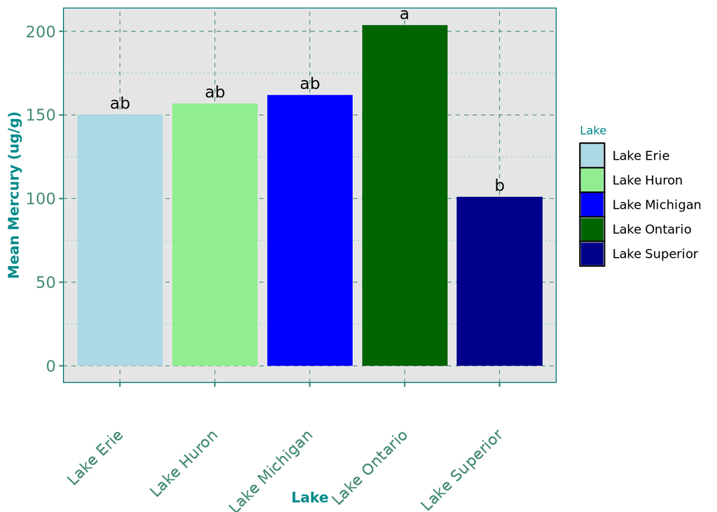

Figure 4.1: Results of Tukey HSD test performed on ANOVA of Mercury levels in sampled fish from each of the Great Lakes.

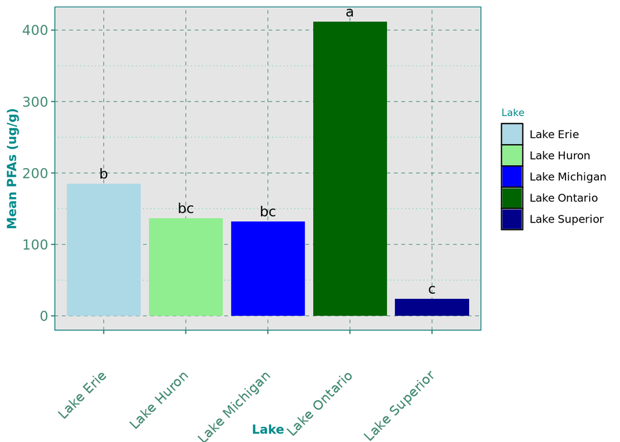

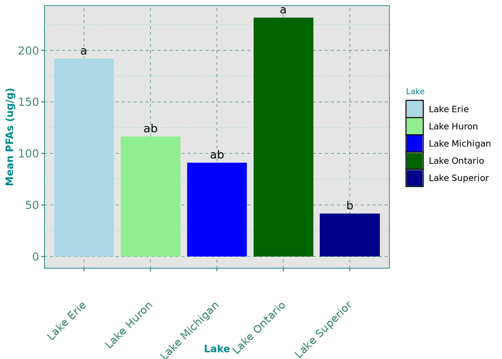

Figure 4.3: Results of Tukey HSD test performed on ANOVA of PFA levels in sampled fish from each of the Great Lakes.

From this analysis, it is apparent that Lakes Erie, Huron, and Michigan tend to have contaminant means that are not statistically different from each other, while Lakes Ontario and Superior more often had significantly different means from them.  
## Question 2: Are there trends in contaminant levels in each fish species over time?  
To investigate the presence of potential trends in each over time, we use **linear regressions**. Unfortunately, with only three sample years, there is not sufficient data for a time series. Instead, we search for meaningful results of linear regression models. **We focus only on fish species for which there is data for all three sample years.** We determined which fish had data for all three years using the results from our exploratory anaylses. 14 fish species qualified for this analysis (Brown Trout, Channel Catfish, Chinook Salmon, Coho Salmon, Freshwater Drum, Lake Trout, Lake Whitefish, Longnose Sucker, Rainbow Trout, Smallmouth Bass, Walleye, White Perch, White Sucker, and Yellow Perch). We run 3 models, one for each contaminant (again excluding Fatty Acids for the aforementioned reasons), inputting “contaminant amount” as the dependent variable, “Year” as the dependent variable, and “Fish Species” as the grouping variable into the regression.  
The mean mercury values for each species were plotted over time, with a line of best fit for each species (Figure 4.4). Linear regressions were conducted for each species to assess whether mercury levels changed significantly over the years. However, **none** of the regressions indicated a significant relationship between year and mercury level (all p > 0.05), suggesting no statistically significant trends in mercury levels for these species over time.

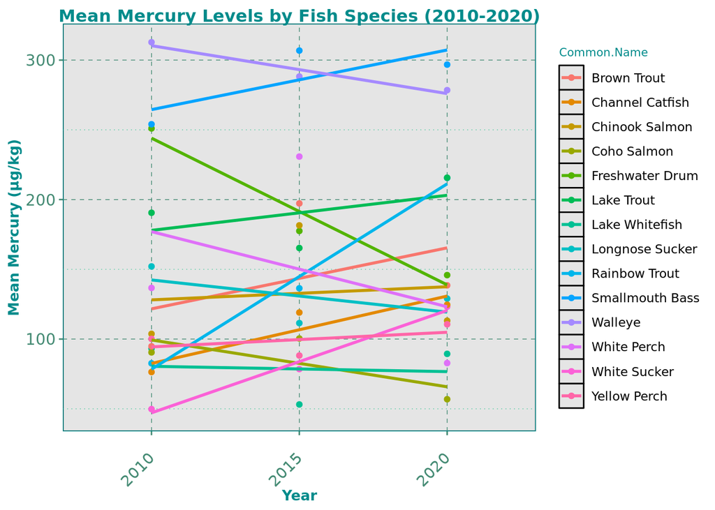

Figure 4.4: Mean mercury levels over time of each fish species sampled in the Great Lakes

This process is repeated for PCBs. The same 14 fish as mercury had data available for all three years (Figure 4.5). Of all 14 fish, only one presented a p-value indicating a significant relationship between PCB level and year for that species. **White Perch** had a p-value of 0.04507 (p<0.5) and an adjusted R-squared value of 0.99.

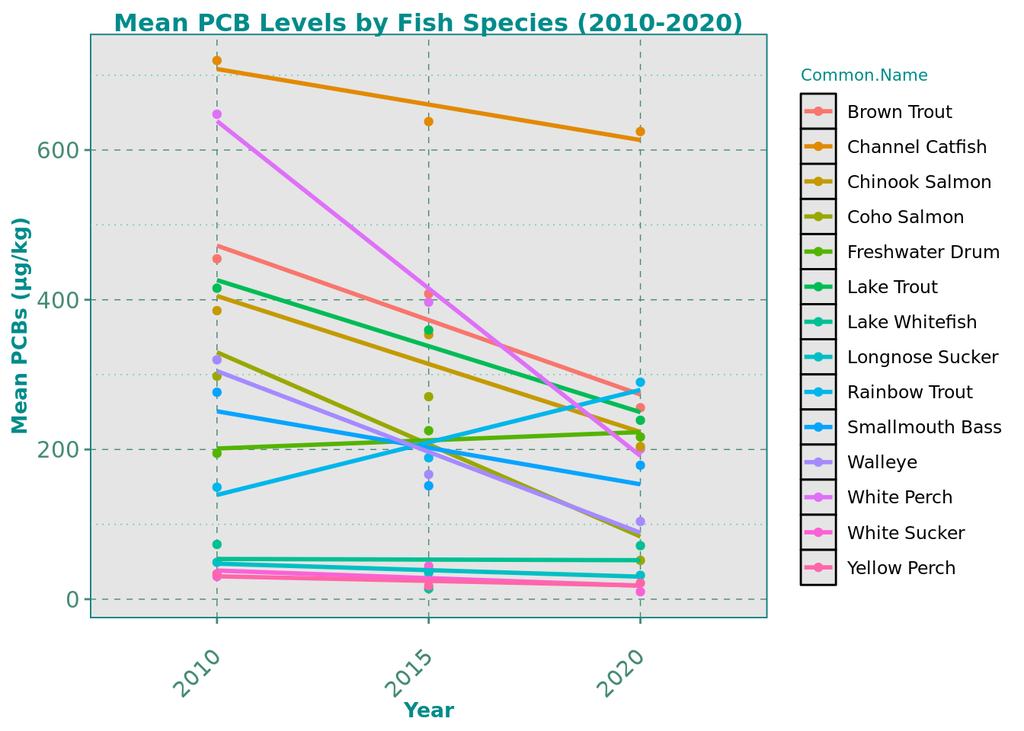

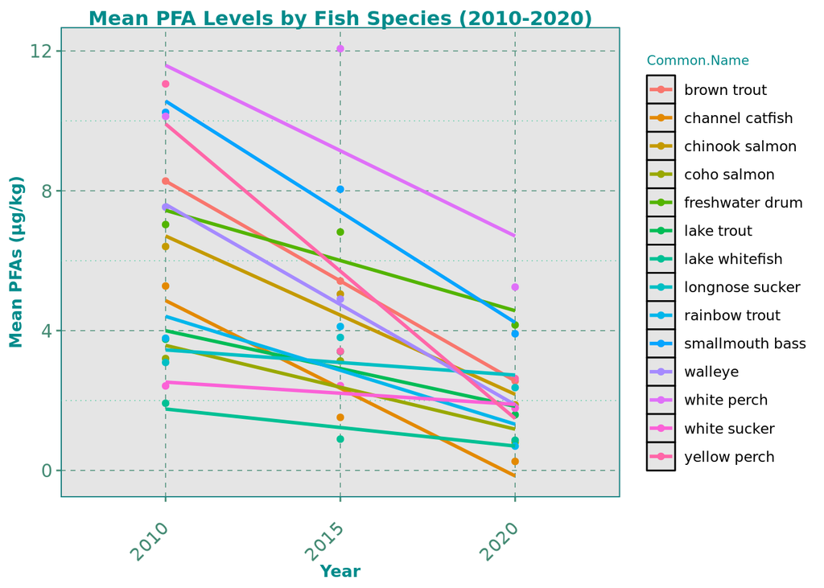

Figure 4.6: Mean PFA levels over time of each fish species sampled in the Great Lakes

From these regressions, we can conclude that there are no species for which year and Mercury level have a significant relationship; there is a significant relationship between year and PCB level only for White Perch; and there is a significant relationship between year and PFA level for Brown Trout and Walleye.

## 4.2 Question 3: How do contaminants vary depending on if fish is an open-sea or bottom dweller (niche)?

To continue our investigation of what may make certain fish more susceptible to contamination, another factor aside from species is the fish niche. In NCCA data collection, there were two options for fish niche: “BD” (Benthic-Demersal- i.e. bottom dweller) and”P” (Pelagic- i.e. open sea). We compare the mean contaminant amounts between BD and P fish across each sampling year using an **ANOVA**. The results of the ANOVA are summarized in Table 4.2 .

Table 4.2: ANOVA results of mean contaminant levels found in fish samples from both Niches from 3 sampling years.

[output not shown]

# 5 Summary and Conclusions

The data collected through the NCCA surveys provide crucial insight into the contamination of fish tissue in the Great Lakes. Using this data, we were able to determine that the levels of contaminants are not evenly distributed across the Great Lakes, as there is significant differences between mean contaminant levels in most cases. Further, certain lakes tend to have contaminant means that are not statistically different from each other (Lakes Erie, Huron, and Michigan), while Lakes Ontario and Superior tend to be statistically different than other lakes. This may be a result of geographic differences in the lakes, or national-level regulations that apply to the lakes that are shared between the U.S. and Canada. The variance between lakes indicates that broad and comprehensive management plans for all of the lakes may not be the best solution for addressing this contamination. Management plans should be tailored to each individual lake, with special attention taken towards the lakes that tend to behave differently. Since the Great Lakes do act as drinking water sources for many communities, it is important that contaminant levels are continuously monitored and mitigated when necessary.  
For our second research question, we found that there are certain fish species that have significnat trends in contaminantion over time, but the number of fish species that do not have significant trends outnumber the ones that do. For Mercury, there were no significant trends, which may be attributed to the capacity for non-discriminatory contamination of this chemical. Mercury may be a threat to all fish, as there may not be any biological differences that can protect certain fish from it. We did find significant relationships between year and White Perch (PCBs), Brown Trout (PFAs), and Walleye (PFAs). For these species, the trends were downward- that is, the amount of contamination is decreasing over time. While more data would be required to support this claim, it is possible that these species are adapting in some way to reduce their contamination levels, potentially through changes in habitat, feeding behaviors, or physiological mechanisms. Continued analysis is needed, especially in consideration of recreational fishing and consumption of fish that would pass on contaminants to the general public.  
Lastly, we found that, in most cases sampled, Pelagic fish had significantly higher means of contamination. Pelagic fish primarily reside and hunt in open waters; recognizing that these fish have higher levels of contaminants may point researchers towards further investigations into environmental factors that contribute to this contamination. Specifically, it may suggest a closer examination of aquatic pollution sources such as industrial discharge, agricultural runoff, or plastic waste (specifically for PFAs) that could be affecting these species.Further, pelagic fish tend to be predators, which indicates the potential consequences of biomagnification, where contaminants increase in concentration as they move up the food chain [8].  
Processing this data revealed a lot about data collected in the field, and the importance of formatting consistency for long-term data sets. While some trends and relationships were found to be significant in our analysis, more data points are required for more confidence. This should be motivation to the EPA to continue the NCCA program, as the current sample size is very small. However, if the trends we found are any indication, the contamination of fish should absolutely continue to be monitored over time, especially given the potential long-term impacts on aquatic ecosystems and human health.

# 6 References

[1]The Great Lakes. (n.d.). National Wildlife Federation. Retrieved December 8, 2024, from https://www.nwf.org/Home/Educational-Resources/Wildlife-Guide/Wild-Places/Great-Lakes  
[2] US EPA, O. (2020, June 11). National Coastal Condition Assessment—Great Lakes Human Health Fish Tissue Studies [Overviews and Factsheets]. https://www.epa.gov/choose-fish-and-shellfish-wisely/national-coastal- condition-assessment-great-lakes-human-health  
[3] US EPA. (2024, April 9). 2020 Great Lakes Human Health Fish Fillet Tissue Study [Overviews and Factsheets]. https://www.epa.gov/choose-fish-and-shellfish-wisely/2020-great-lakes-human-health-fish-fillet-tissue-study  
[4] EPA. (2020, June 15). Quality Assurance Project Plan for National Coastal Condition Assessment (NCCA) 2020 Great Lakes Human Health Fish Sample Preparation.  
[5] Contaminants in Fish. (2021, April 5). Indiana Department of Health. https://www.in.gov/health/eph/fish-consumption-advisory/contaminants-in-fish/  
[6] US EPA, O. (2021, November 16). Per- and Polyfluoroalkyl Substances (PFAS) [Reports and Assessments]. https://www.epa.gov/sdwa/and-polyfluoroalkyl-substances-pfas  
[7] Excess omega-3 fatty acids could lead to negative health effects. (n.d.). Oregon State University College of Health. Retrieved December 12, 2024, from https://synergies.oregonstate.edu/2013/excess-omega-3-fatty-acids-lead-negative-health-effects/  
[8] US Department of Commerce, N. O. and A. A. (n.d.). What are pelagic fish? Retrieved December 12, 2024, from https://oceanservice.noaa.gov/facts/pelagic.html  
[9] Fighting for Our Fisheries. (n.d.). The Nature Conservancy. Retrieved December 12, 2024, from https://www.nature.org/en-us/about-us/where-we-work/priority-landscapes/great-lakes/stories-in-the-great-lakes/great-lakes-fisheries/